# PS06 pre-lecture: multiple regression

## Multiple regression

more than one explanatory variable, with **moderndive**

two models, one question `+ vs *`

- `lm(y ~ x1 + x2)`
- `lm(y ~ x1 * x2)`
- `geom_parallel_slopes()`
- `coef()`

Fertility rate, life expectancy, and income group

## Why add a variable?

Hold The Other One Fixed

- A slope in simple regression ignores everything else.
- In multiple regression each slope holds the **other** variables fixed.
- Adding a categorical variable gives each group its own intercept.
- Adding an interaction gives each group its own **slope** too.

## y ~ x1 + x2

Parallel Slopes

One slope for everybody, shifted up or down by group.

## lm()

Example

the verb (function) gives each group its own intercept

```r
model_no_int <- lm(fert_rate ~ life_exp + income, data = UN_data_ch6)
```

response ~ numerical + categorical the data frame

## geom_parallel_slopes()

Example

one color per group

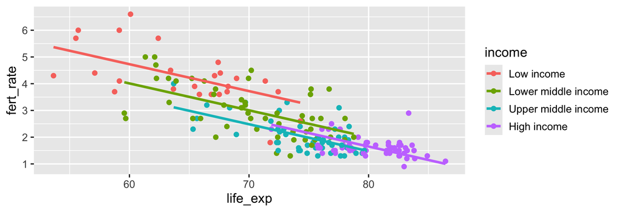

```r
ggplot(UN_data_ch6, aes(x = life_exp, y = fert_rate, color = income)) +
  geom_point() +
  geom_parallel_slopes(se = FALSE)
```

one line per group, all the same slope

## y ~ x1 * x2

Interaction

Use it when the effect of x differs from group to group.

## lm()

Example

the verb (function) interaction: slopes differ too

```r
model_int <- lm(fert_rate ~ life_exp * income,
                data = UN_data_ch6)
```

the data frame

## coef()

Example

the fitted model

```r
coef(model_int)
```

```
                       (Intercept)                           life_exp
                       11.91826460                        -0.11848075
         incomeLower middle income          incomeUpper middle income
                       -1.50420617                        -1.89291757
                 incomeHigh income life_exp:incomeLower middle income
                       -6.57953685                         0.01265027
life_exp:incomeUpper middle income         life_exp:incomeHigh income
                        0.01117481                         0.07221696
```

the verb (function)

## Reading the coefficients

Baseline & Offsets

- The **(Intercept)** entry belongs to the baseline group.
- A group’s entry is how far its intercept sits from the baseline.
- In an interaction model, an **x:group** entry shifts that group’s slope.
- Add the offset to the baseline to get the group’s own value.

## Which model?

Parallel Or Interaction

- Plot the data colored by group before fitting anything.
- If the clouds trend at visibly different angles, try the interaction.
- If the lines would be nearly parallel anyway, the simpler model wins.
- Compare the two fitted models’ coefficients side by side with **coef()**.